# Tratamiento datos COVID-19 México 17/04/2020

Viacheslav Shalisko

17/4/2020

### Datos fuente

datos abiertos SSA https://www.gob.mx/salud/documentos/datos-abiertos-152127

### Fuentes auxiliares

Diccionarios de datos SSA https://www.gob.mx/salud/documentos/datos-abiertos-152127 y Catálogo Único de Claves de Áreas Geoestadísticas Estatales, Municipales y Localidades de INEGI https://www.inegi.org.mx/app/ageeml/

## Total de casos positivos

### Total de casos registrados para 17 de abril del 2020: 6875; aumento: 578.

## Resumen de registros positivos por estado

Tabla. Casos confirmados por estado para 17 de abril del 2020

| ID | Estado | Total de casos confirmados | Casos para ayer | Aumento de casos | Casos por 100k habitantes |
| --- | --- | --- | --- | --- | --- |
| 1 | AGUASCALIENTES | 77 | 71 | 6 | 6.5 |
| 2 | BAJA CALIFORNIA | 534 | 504 | 30 | 16.9 |
| 3 | BAJA CALIFORNIA SUR | 169 | 166 | 3 | 26.5 |
| 4 | CAMPECHE | 29 | 28 | 1 | 3.5 |
| 7 | CHIAPAS | 60 | 55 | 5 | 1.3 |
| 8 | CHIHUAHUA | 114 | 107 | 7 | 3.3 |
| 9 | CIUDAD DE MÉXICO | 1804 | 1592 | 212 | 20.4 |
| 5 | COAHUILA DE ZARAGOZA | 223 | 220 | 3 | 8.1 |
| 6 | COLIMA | 10 | 8 | 2 | 1.5 |
| 10 | DURANGO | 20 | 18 | 2 | 1.2 |
| 11 | GUANAJUATO | 114 | 97 | 17 | 2.1 |
| 12 | GUERRERO | 112 | 103 | 9 | 3.3 |
| 13 | HIDALGO | 75 | 69 | 6 | 2.8 |
| 14 | JALISCO | 189 | 180 | 9 | 2.6 |
| 15 | MÉXICO | 1002 | 903 | 99 | 6.6 |
| 16 | MICHOACÁN DE OCAMPO | 100 | 85 | 15 | 2.3 |
| 17 | MORELOS | 81 | 65 | 16 | 4.6 |
| 18 | NAYARIT | 35 | 31 | 4 | 3.2 |
| 19 | NUEVO LEÓN | 156 | 156 | 0 | 3.4 |
| 20 | OAXACA | 57 | 54 | 3 | 1.5 |
| 21 | PUEBLA | 315 | 307 | 8 | 5.4 |
| 22 | QUERÉTARO | 77 | 74 | 3 | 4.2 |
| 23 | QUINTANA ROO | 282 | 279 | 3 | 21.3 |
| 24 | SAN LUIS POTOSÍ | 57 | 55 | 2 | 2.2 |
| 25 | SINALOA | 372 | 326 | 46 | 13.4 |
| 26 | SONORA | 101 | 91 | 10 | 3.8 |
| 27 | TABASCO | 255 | 238 | 17 | 11.4 |
| 28 | TAMAULIPAS | 95 | 82 | 13 | 2.9 |
| 29 | TLAXCALA | 62 | 58 | 4 | 5.3 |
| 30 | VERACRUZ DE IGNACIO DE LA LLAVE | 130 | 121 | 9 | 1.7 |
| 31 | YUCATÁN | 145 | 136 | 9 | 7.4 |
| 32 | ZACATECAS | 23 | 18 | 5 | 1.5 |

# Histogramas de registros positivos por estado

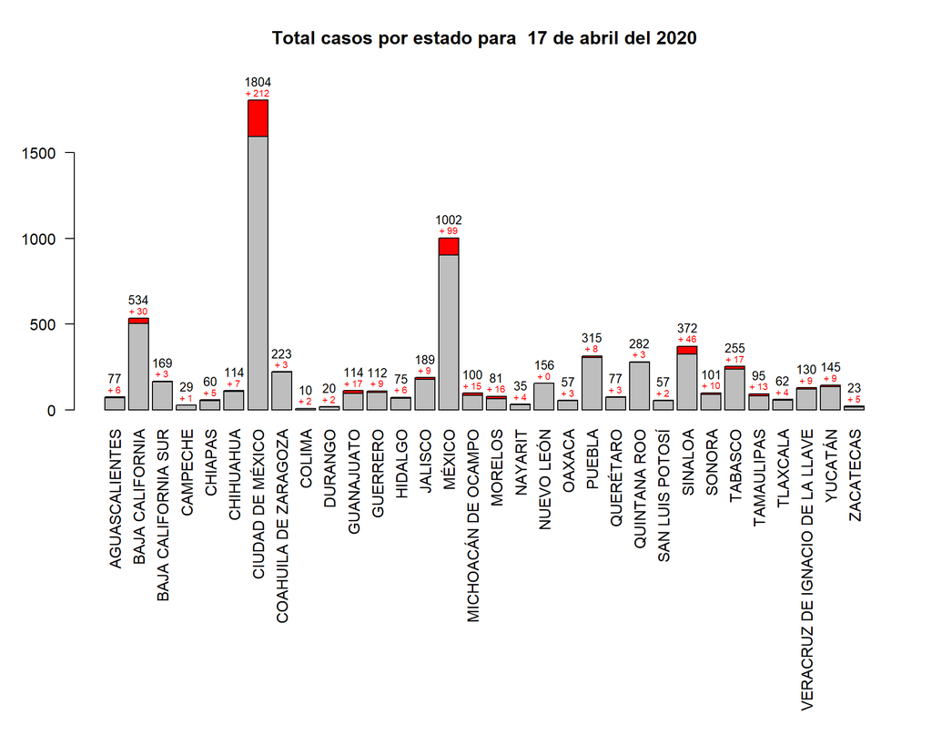

# Histogramas de registros positivos por estado (2)

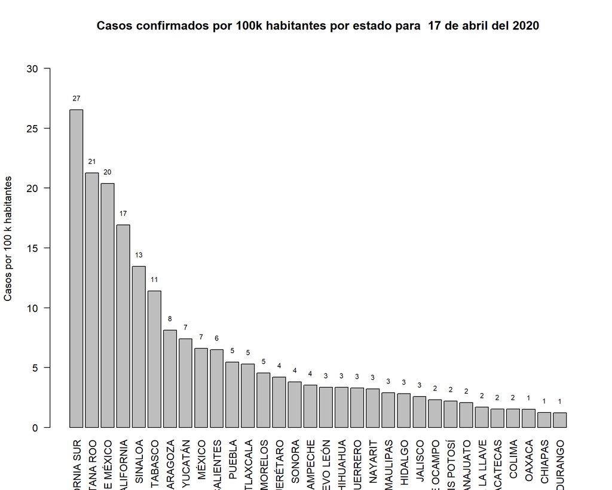

# Total de defunciones

### Total de defunciones registrados para 17 de abril del 2020: 544; aumento: 58.

## Resumen de defunciones por estado

Tabla. Defunciones por estado para 17 de abril del 2020

| ID | Estado | Total de defunciones | Defunciones para ayer | Aumento |
| --- | --- | --- | --- | --- |
| 1 | AGUASCALIENTES | 2 | 2 | 0 |
| 2 | BAJA CALIFORNIA | 32 | 30 | 2 |
| 3 | BAJA CALIFORNIA SUR | 6 | 6 | 0 |
| 4 | CAMPECHE | 2 | 2 | 0 |
| 7 | CHIAPAS | 3 | 3 | 0 |
| 8 | CHIHUAHUA | 26 | 23 | 3 |
| 9 | CIUDAD DE MÉXICO | 126 | 102 | 24 |
| 5 | COAHUILA DE ZARAGOZA | 16 | 16 | 0 |
| 10 | DURANGO | 4 | 4 | 0 |
| 11 | GUANAJUATO | 7 | 6 | 1 |
| 12 | GUERRERO | 11 | 9 | 2 |
| 13 | HIDALGO | 11 | 10 | 1 |
| 14 | JALISCO | 13 | 11 | 2 |
| 15 | MÉXICO | 60 | 55 | 5 |
| 16 | MICHOACÁN DE OCAMPO | 14 | 13 | 1 |
| 17 | MORELOS | 10 | 10 | 0 |
| 18 | NAYARIT | 5 | 5 | 0 |
| 19 | NUEVO LEÓN | 4 | 4 | 0 |
| 20 | OAXACA | 4 | 4 | 0 |
| 21 | PUEBLA | 39 | 34 | 5 |
| 22 | QUERÉTARO | 6 | 5 | 1 |
| 23 | QUINTANA ROO | 31 | 28 | 3 |
| 24 | SAN LUIS POTOSÍ | 4 | 4 | 0 |
| 25 | SINALOA | 43 | 40 | 3 |
| 26 | SONORA | 11 | 11 | 0 |
| 27 | TABASCO | 28 | 26 | 2 |
| 28 | TAMAULIPAS | 5 | 4 | 1 |
| 29 | TLAXCALA | 4 | 4 | 0 |
| 30 | VERACRUZ DE IGNACIO DE LA LLAVE | 7 | 6 | 1 |
| 31 | YUCATÁN | 8 | 7 | 1 |
| 32 | ZACATECAS | 2 | 2 | 0 |

# Histogramas de defunciones por estado

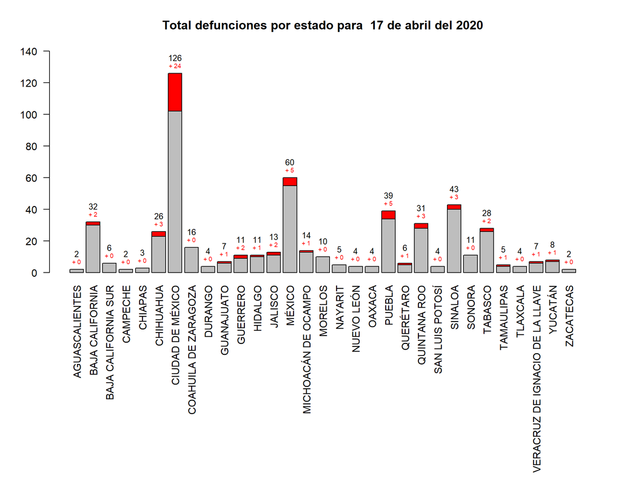

# Total de pruebas realizadas

### Total de pruebas con resultado negativo registrados para 17 de abril del 2020: 28126; aumento: -472.

### Total de pruebas con resultado para 17 de abril del 2020: 35001; aumento: 106

## Resumen de pruebas por estado

Tabla. Pruebas por estado para 17 de abril del 2020

| ID | Estado | Total de pruebas negativas | Nuevos negativos | Total de pruebas positivas | Nuevos positivos | Total de pruebas | Pruebas nuevas | % de positiovs | % de positivos en pruebas nuevas | Pruebas por 100k habitantes |
| --- | --- | --- | --- | --- | --- | --- | --- | --- | --- | --- |
| 1 | AGUASCALIENTES | 816 | 28 | 77 | 6 | 893 | 34 | 8.62 | 15.00 | 81.77 |
| 2 | BAJA CALIFORNIA | 833 | -85 | 534 | 30 | 1367 | -55 | 39.06 | -120.00 | 71.82 |
| 3 | BAJA CALIFORNIA SUR | 519 | -29 | 169 | 3 | 688 | -26 | 24.56 | -13.04 | 157.92 |
| 4 | CAMPECHE | 124 | 13 | 29 | 1 | 153 | 14 | 18.95 | 6.67 | 23.10 |
| 7 | CHIAPAS | 278 | -13 | 60 | 5 | 338 | -8 | 17.75 | -166.67 | 8.46 |
| 8 | CHIHUAHUA | 284 | -12 | 114 | 7 | 398 | -5 | 28.64 | 350.00 | 19.17 |
| 9 | CIUDAD DE MÉXICO | 5050 | -97 | 1804 | 212 | 6854 | 115 | 26.32 | 64.83 | 104.54 |
| 5 | COAHUILA DE ZARAGOZA | 1229 | 44 | 223 | 3 | 1452 | 47 | 15.36 | 6.00 | 88.96 |
| 6 | COLIMA | 101 | 3 | 10 | 2 | 111 | 5 | 9.01 | 28.57 | 21.06 |
| 10 | DURANGO | 279 | -27 | 20 | 2 | 299 | -25 | 6.69 | -8.70 | 24.43 |
| 11 | GUANAJUATO | 1733 | 66 | 114 | 17 | 1847 | 83 | 6.17 | 17.00 | 37.78 |
| 12 | GUERRERO | 341 | 14 | 112 | 9 | 453 | 23 | 24.72 | 28.12 | 17.20 |
| 13 | HIDALGO | 405 | 1 | 75 | 6 | 480 | 7 | 15.62 | 46.15 | 20.41 |
| 14 | JALISCO | 2586 | -122 | 189 | 9 | 2775 | -113 | 6.81 | -8.65 | 45.26 |
| 15 | MÉXICO | 2645 | -231 | 1002 | 99 | 3647 | -132 | 27.47 | -300.00 | 35.42 |
| 16 | MICHOACÁN DE OCAMPO | 591 | 84 | 100 | 15 | 691 | 99 | 14.47 | 13.16 | 21.74 |
| 17 | MORELOS | 331 | 0 | 81 | 16 | 412 | 16 | 19.66 | 50.00 | 27.12 |
| 18 | NAYARIT | 200 | 8 | 35 | 4 | 235 | 12 | 14.89 | 25.00 | 26.91 |
| 19 | NUEVO LEÓN | 2082 | 10 | 156 | 0 | 2238 | 10 | 6.97 | 0.00 | 95.91 |
| 20 | OAXACA | 364 | -7 | 57 | 3 | 421 | -4 | 13.54 | -300.00 | 12.99 |
| 21 | PUEBLA | 890 | -3 | 315 | 8 | 1205 | 5 | 26.14 | 61.54 | 27.13 |
| 22 | QUERÉTARO | 449 | -12 | 77 | 3 | 526 | -9 | 14.64 | -50.00 | 33.43 |
| 23 | QUINTANA ROO | 433 | -42 | 282 | 3 | 715 | -39 | 39.44 | -8.33 | 71.67 |
| 24 | SAN LUIS POTOSÍ | 925 | 12 | 57 | 2 | 982 | 14 | 5.80 | 12.50 | 42.16 |
| 25 | SINALOA | 780 | -17 | 372 | 46 | 1152 | 29 | 32.29 | 61.33 | 54.12 |
| 26 | SONORA | 544 | -15 | 101 | 10 | 645 | -5 | 15.66 | 200.00 | 31.62 |
| 27 | TABASCO | 512 | -41 | 255 | 17 | 767 | -24 | 33.25 | -242.86 | 50.88 |
| 28 | TAMAULIPAS | 623 | 33 | 95 | 13 | 718 | 46 | 13.23 | 22.03 | 29.34 |
| 29 | TLAXCALA | 399 | 24 | 62 | 4 | 461 | 28 | 13.45 | 12.50 | 47.35 |
| 30 | VERACRUZ DE IGNACIO DE LA LLAVE | 937 | -57 | 130 | 9 | 1067 | -48 | 12.18 | -23.08 | 20.46 |
| 31 | YUCATÁN | 551 | 1 | 145 | 9 | 696 | 10 | 20.83 | 47.37 | 46.53 |
| 32 | ZACATECAS | 292 | -3 | 23 | 5 | 315 | 2 | 7.30 | 71.43 | 25.22 |

# Histogramas de pruebas por estado

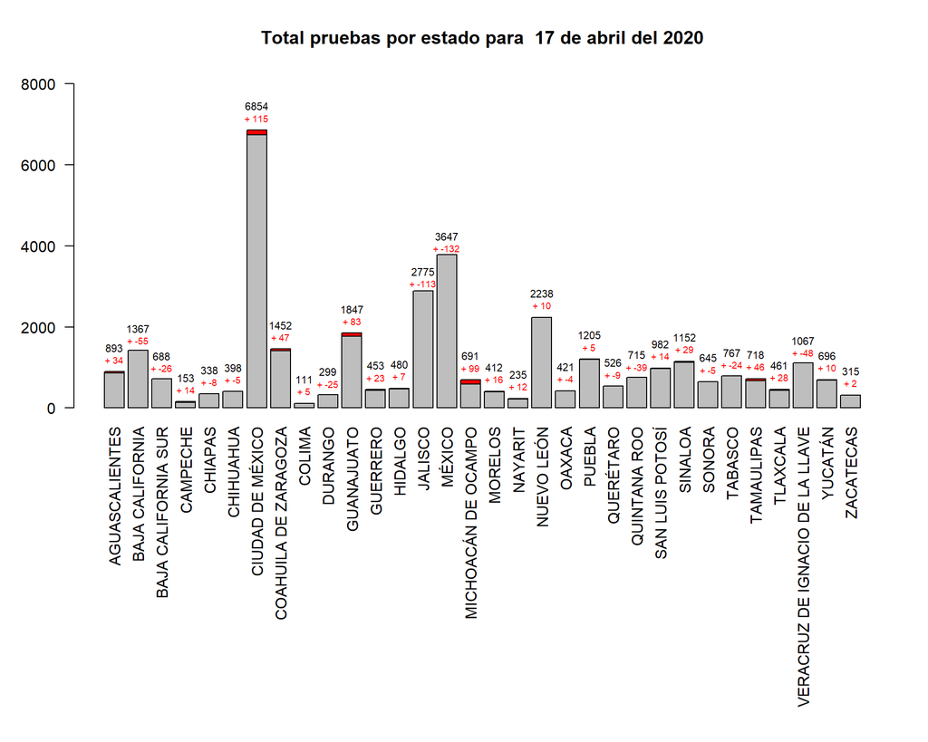

# Histogramas de pruebas por estado (2)

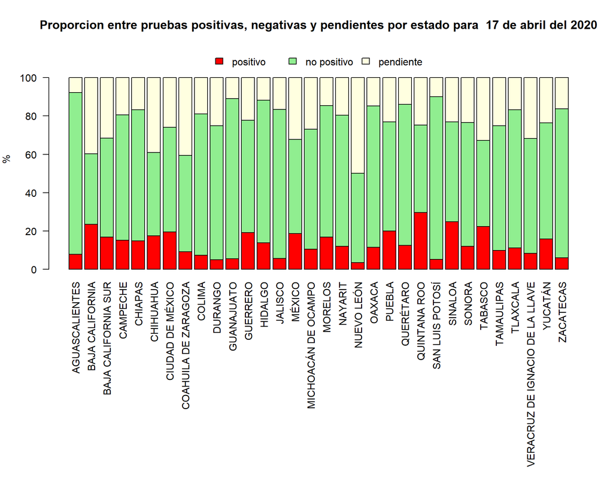

# Histogramas de pruebas por estado (3)

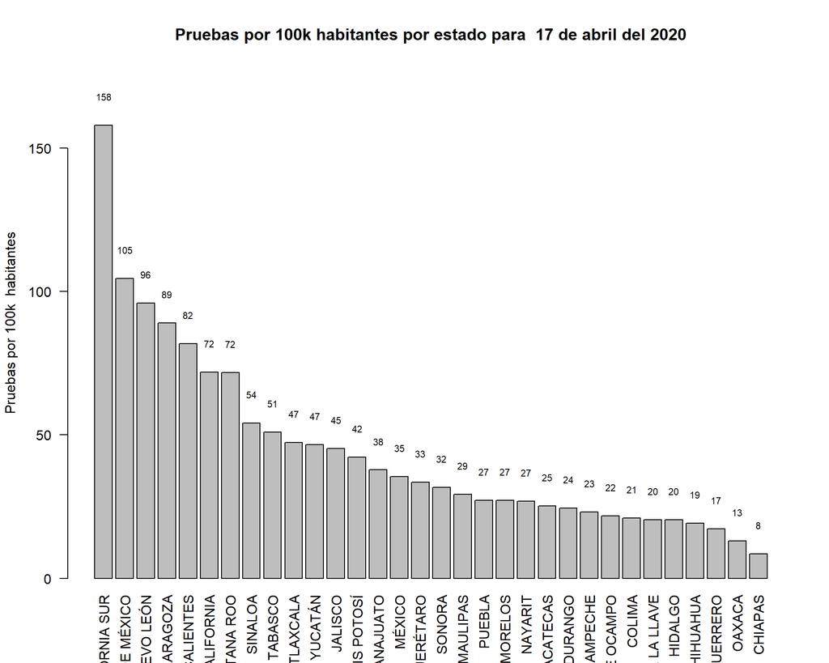

# Relación entre número de casos confirmados y numero de pruebas por estados de México

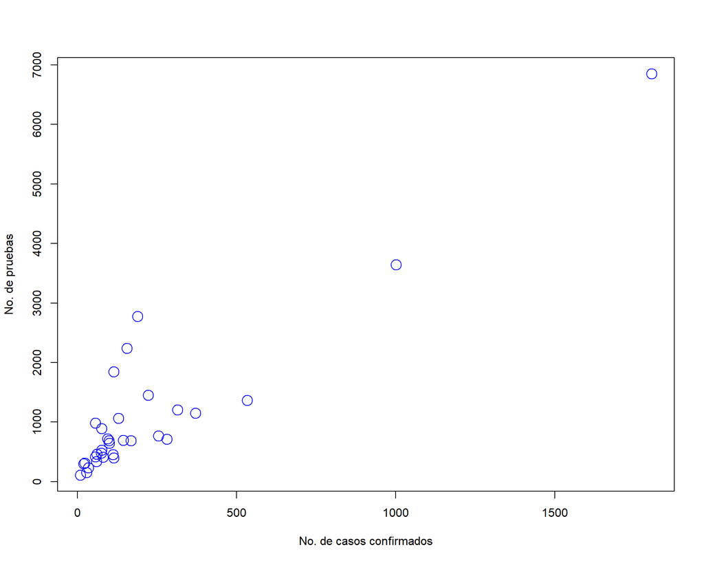

# Relación entre número de casos, numero de pruebas y porcentaje de pruebas positivas por estados de México

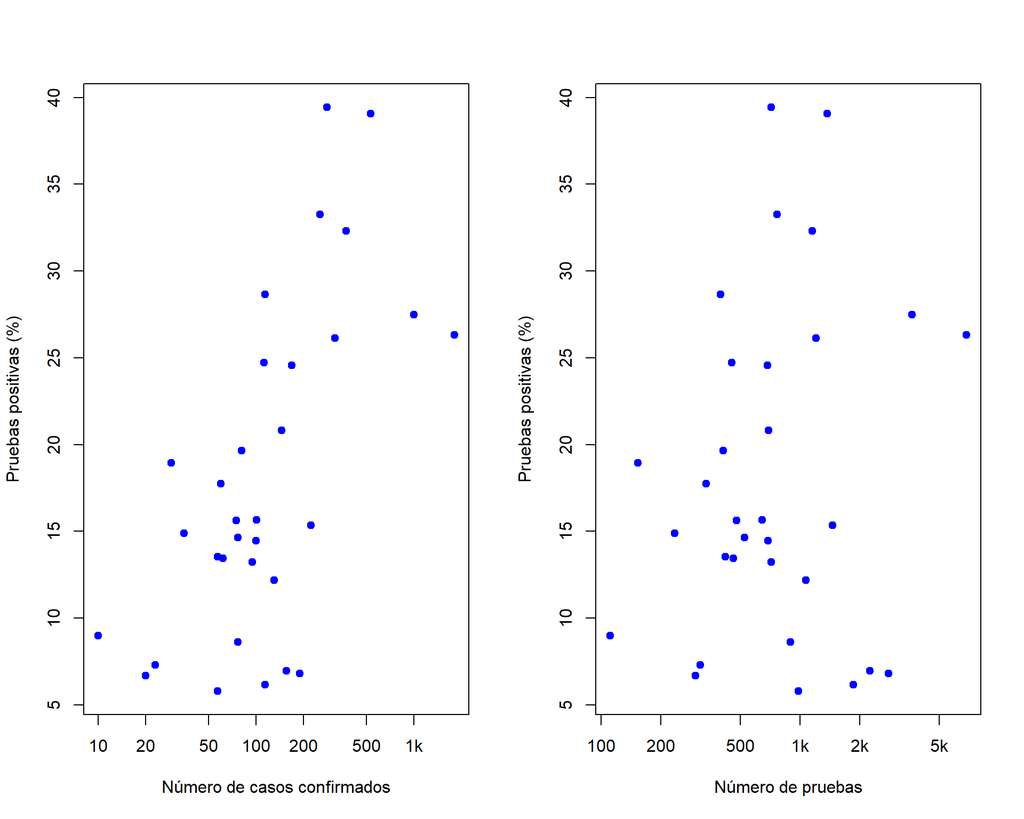

# Tabla de registros positivos por municipio

Tabla. Los cien municipios con mayór incidencia para 17 de abril del 2020

| Casos confirmados | Aumento casos | Casos por 100k habitantes | Defunciones | Aumento def. | Pruebas negativas | % de pruebas positivas | Pruebas por 100k habitantes | Localidad | Municipio | Estado |
| --- | --- | --- | --- | --- | --- | --- | --- | --- | --- | --- |
| 294 | 14 | 21.8 | 19 | 2 | 351 | 45.6 | 87.8 | Tijuana | TIJUANA | BC |
| 284 | 37 | 33.1 | 29 | 2 | 396 | 41.8 | 104.5 | Culiacán Rosales | CULIACÁN | SL |
| 255 | 43 | 14.0 | 23 | 4 | 590 | 30.2 | 65.9 | Iztapalapa | IZTAPALAPA | DF |
| 214 | 14 | 24.7 | 9 | 0 | 294 | 42.1 | 91.5 | Mexicali | MEXICALI | BC |
| 208 | 15 | 17.5 | 24 | 8 | 524 | 28.4 | 92.2 | Gustavo A. Madero | GUSTAVO A. MADERO | DF |
| 202 | 1 | 31.3 | 15 | 0 | 244 | 45.3 | 94.0 | Cancún | BENITO JUÁREZ | QR |
| 199 | 3 | 12.9 | 22 | 3 | 514 | 27.9 | 60.2 | Heroica Puebla de Zaragoza | PUEBLA | PL |
| 166 | 10 | 25.9 | 16 | 1 | 377 | 30.6 | 111.8 | Villahermosa | CENTRO | TC |
| 160 | 12 | 42.9 | 4 | 0 | 347 | 31.6 | 156.3 | Miguel Hidalgo | MIGUEL HIDALGO | DF |
| 156 | 22 | 24.0 | 7 | 1 | 365 | 29.9 | 110.8 | Tlalpan | TLALPAN | DF |
| 146 | 28 | 20.1 | 14 | 2 | 418 | 25.9 | 99.8 | Álvaro Obregón | ÁLVARO OBREGÓN | DF |
| 134 | 12 | 25.2 | 11 | 1 | 363 | 27.0 | 121.7 | Cuauhtémoc | CUAUHTÉMOC | DF |
| 119 | 5 | 14.4 | 4 | 1 | 423 | 22.0 | 87.6 | Mérida | MÉRIDA | YN |
| 117 | 1 | 78.3 | 2 | 0 | 247 | 32.1 | 345.9 | San José del Cabo | LOS CABOS | BS |
| 117 | 12 | 10.5 | 9 | 3 | 258 | 31.2 | 53.7 | Ciudad Nezahualcóyotl | NEZAHUALCÓYOTL | MC |
| 113 | 2 | 52.3 | 9 | 0 | 284 | 28.5 | 296.8 | Monclova | MONCLOVA | CL |
| 113 | 15 | 18.2 | 6 | 1 | 341 | 24.9 | 98.3 | Coyoacán | COYOACÁN | DF |
| 108 | 16 | 6.5 | 3 | 0 | 281 | 27.8 | 35.0 | Ecatepec de Morelos | ECATEPEC DE MORELOS | MC |
| 96 | 4 | 51.5 | 1 | 0 | 149 | 39.2 | 157.8 | Cuajimalpa de Morelos | CUAJIMALPA DE MORELOS | DF |
| 91 | 5 | 23.6 | 3 | 0 | 422 | 17.7 | 160.6 | Benito Juárez | BENITO JUÁREZ | DF |
| 86 | 11 | 20.7 | 5 | 2 | 280 | 23.5 | 115.7 | Azcapotzalco | AZCAPOTZALCO | DF |
| 86 | 11 | 20.0 | 8 | 3 | 231 | 27.1 | 96.3 | Venustiano Carranza | VENUSTIANO CARRANZA | DF |
| 86 | 8 | 10.3 | 4 | 0 | 257 | 25.1 | 56.4 | Naucalpan de Juárez | NAUCALPAN DE JUÁREZ | MC |
| 83 | 6 | 20.0 | 8 | 1 | 281 | 22.8 | 125.4 | Xochimilco | XOCHIMILCO | DF |
| 82 | 5 | 12.3 | 1 | 0 | 206 | 28.5 | 62.0 | Tlalnepantla | TLALNEPANTLA DE BAZ | MC |
| 76 | 10 | 19.8 | 5 | 0 | 208 | 26.8 | 110.1 | Iztacalco | IZTACALCO | DF |
| 75 | 2 | 5.6 | 22 | 0 | 135 | 35.7 | 27.9 | Juárez | JUÁREZ | CH |
| 68 | 4 | 4.5 | 4 | 1 | 743 | 8.4 | 64.3 | Guadalajara | GUADALAJARA | JC |
| 66 | 6 | 8.4 | 2 | 0 | 648 | 9.2 | 98.1 | Aguascalientes | AGUASCALIENTES | AS |
| 62 | 3 | 8.0 | 5 | 1 | 294 | 17.4 | 55.3 | Santiago de Querétaro | QUERÉTARO | QT |

[output cut: 70 more lines]

# Relación entre número de casos confirmados y numero de pruebas por municipios de México

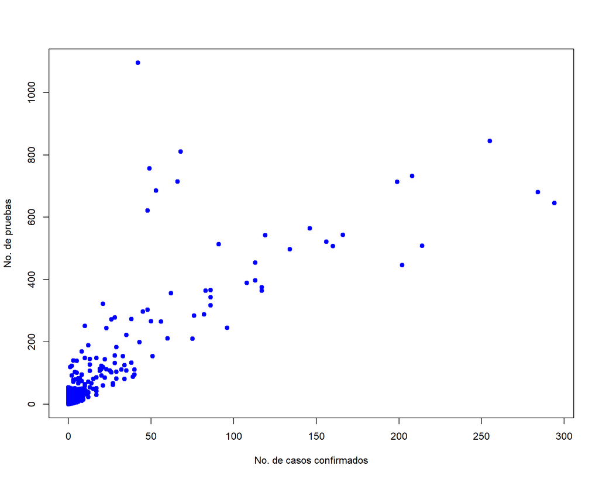

# Relación entre número de casos, numero de pruebas y porcentaje de pruebas positivas por municipios de México

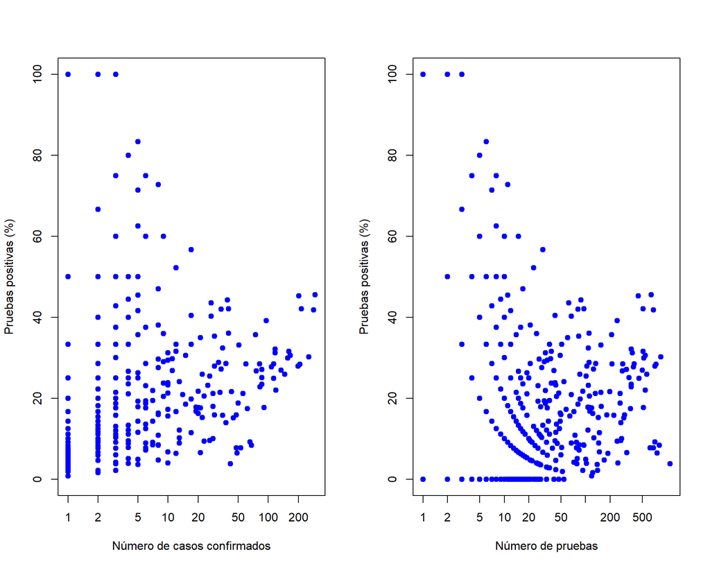

# Mapa de pruebas: número de pruebas para COVID-19 y % de positividad por municipio para 17 de abril del 2020

[interactive chart not shown]

# Mapa de casos confirmados de COVID-19 por municipio para 17 de abril del 2020

[interactive chart not shown]

# Mapa de defunciones por COVID-19 por municipio para 17 de abril del 2020

[interactive chart not shown]